# Homework 5

Due by 11:00pm on February 23, 2023

For submission instructions, see: http://faculty.washington.edu/rjl/classes/am574w2023/homework5.html

Ideally you will do this homework by modifying this Jupyter notebook `$AM574/homeworks/hw5/hw5.ipynb` to fill in the solutions, with plots to accompany your results. If necessary you can scan some handwritten things instead.

```python
%matplotlib inline
from pylab import *
from IPython.display import HTML

try:
    from clawpack.visclaw import animation_tools
except:
    print("Failed to load animation_tools from Clawpack")
```

## Isothermal p-system

All of the problems below concern the same nonlinear hyperbolic system $q_t + f(q)_x=0$ given by the p-system arising from Lagrangian gas dynamics (2.108) in the case of isothermal flow (as in Problem 2.8(b) from hw1):

$$ \begin{split} v_t - u_x &= 0,\\ u_t + (a^2/v)_x &=0. \end{split} $$

Write out formulas for general values of $a$ but use $a=2$ for the specific examples.

Note that these curves agree well near the points $(v_*,u_*)$ but are not identical farther away.

You will be asked to produce a similar figure and this shows what you are aiming for.

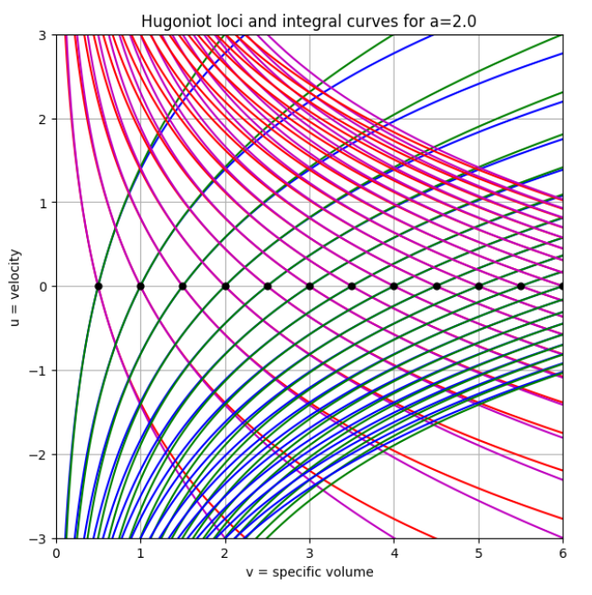

```python
from IPython.display import Image
Image('isothermal1.png', width=500)
```

**Question 1.**

Work out the flux Jacobian and its eigenvalues and eigenvectors. Show that both characteristic families are genuinely nonlinear.

**Solution:**

We have the flux $$f(q)=\begin{bmatrix}-u \\ a^2/v \end{bmatrix}, $$ where $q=(v,u)^T.$ We now calculate the Jacobian, $$J(f)=\begin{bmatrix}0&-1 \\ -a^2/v^2 & 0 \end{bmatrix}.$$ It's clear that we have eigenvalues: $$\lambda^1= -\frac{a}{|v|},~~~~\lambda^2= \frac{a}{|v|}.$$ We will only look at $v>0$, but for $v<0$ we have similar solutions. The eigenvector are found as follows: $$\begin{bmatrix}\frac{a}{v}&-1 \\ -a^2/v^2 & \frac{a}{v} \end{bmatrix}\begin{bmatrix} r_1^1\\r^1_2\end{bmatrix}=0\Rightarrow r^1=\begin{bmatrix}1\\\frac{a}{v} \end{bmatrix}, $$ and $$\begin{bmatrix}-\frac{a}{v}&-1 \\ -a^2/v^2 & -\frac{a}{v} \end{bmatrix}\begin{bmatrix} r_1^2\\r^2_2\end{bmatrix}=0\Rightarrow r^2=\begin{bmatrix}1\\-\frac{a}{v} \end{bmatrix}. $$ We now see that $$\nabla\lambda^1(q)\cdot r^1(q)=\begin{bmatrix}\frac{a}{v^2}\\ 0\end{bmatrix}>0, ~~\forall q, $$ and $$\nabla\lambda^2(q)\cdot r^2(q)=\begin{bmatrix}-\frac{a}{v^2}\\ 0\end{bmatrix}<0, ~~\forall q. $$ Note, in particular, that both are never equal to zero when $q$, or $v$, is equal to anything finite (our region of interest). Both characteristic families are thus genuinely nonlinear.

**Question 2.**

Following Section 13.8.1, work out the equations for the integral curves of the eigenvectors through an arbitrary point $(v_*, u_*)$, e.g. specifying $u(v)$ as $v$ varies (with $u(v_*) = u_*$). You may find it convenient to use this to define Python functions `uint1(v,vstar,ustar,a)`, `uint2(v,vstar,ustar,a)`, so that you can easily plot these as functions of $v$.

**Solution:**

We want to find the integral curves of the vector fields for both eigenvectors. This means that we're going to find the tangent vectors at all points $\tilde{q}(\xi)$ to the curve, $q'(\xi)$, where they are eigenvectors of $f'(\tilde{q}(\xi))$ corresponding to the eigenvalue in $\tilde{q}(\xi)$. Thus we want to find $q'(\xi)$ to be a multiple of the eigenvectors: $$\tilde{q}'(\xi)\sim r^p(\tilde{q}(\xi)), ~~p=1,2.$$ Take $(v_*,u_*)$ fixed. For the first eigenvector family, we get $$\begin{cases}(\tilde{q}^1)'&=1\\ (\tilde{q}^2)'&=\frac{a}{\tilde{q}^1} \end{cases}\Rightarrow \begin{cases}\tilde{q}^1&=\xi\\ (\tilde{q}^2)'&=\frac{a}{\xi} \end{cases}\Rightarrow\begin{cases}\tilde{q}^1&=\xi\\ \tilde{q}^2&=\ln(|\xi|^a)-\ln(|v_*|^a)+u_*. \end{cases}$$ In the last case, the second part of $\tilde{q},$ we want we got it because we want $u(v_*)=u_*$. Taking $v$ as $\xi$ now, since $q^1=v,$ we have. Thus, the first integral curve is $$u(v)= \ln(|v|^a)-\ln(|v_*|^a)+u_*.$$ Now for the second eigenvector family, we get $$\begin{cases}(\tilde{q}^1)'&=1\\ (\tilde{q}^2)'&=-\frac{a}{q^1} \end{cases}\Rightarrow \begin{cases}\tilde{q}^1&=\xi\\ (\tilde{q}^2)'&=-\frac{a}{\xi} \end{cases}\Rightarrow\begin{cases}\tilde{q}^1&=\xi\\ \tilde{q}^2&=\ln(|\xi|^{-a})-\ln(|v_*|^{-a})+u_*. \end{cases}$$ In the last case, the second part of $\tilde{q},$ we want we got it because we want $u(v_*)=u_*$. Taking $v$ as $\xi$ now, since $q^1=v,$ we have. Thus, the second integral curve is $$u(v)= \ln(|v|^{-a})-\ln(|v_*|^{-a})+u_*.$$ In conclusion, we have the two integral curves $$u^1(v)= \ln(|v|^a)-\ln(|v_*|^a)+u_*\text{ and }u^2(v)= -\ln(|v|^a)+\ln(|v_*|^a)+u_*$$

```python
def uint1(v,vstar,ustar,a):
    u = log(abs(v)**a)-log(abs(vstar)**a)+ustar

    plot(v, u, 'b-', label = '1-integral curve')
    return u
```

```python
def uint2(v,vstar,ustar,a):
    u = -log(abs(v)**(a))+log(abs(vstar)**(a))+ustar

    plot(v, u, 'r-', label = '2-integral curve')

    return u
```

**Question 3.**

Determine similar equations for the Hugoniot loci through an arbitrary point $(v_*, u_*)$, e.g. specifying $v(u)$ as $u$ varies away from $u_*$. You may find it convenient to use this to define Python functions `uhug1(v,vstar,ustar)`, `uhug2(v,vstar,ustar)`, so that you can easily plot these as functions of $v$.

Also give the formula for the shock speed $s(v)$ for any point $(v,u(v))$ along this curve and show that this can be written as

$$ s(v)= \pm \frac{a}{\sqrt{vv_*}}. $$

(Note that, as expected, this converges to the corresponding eigenvalue as $v \rightarrow v_*$.)

**Solution:**

From the Hugoniot Rankine conditions, $$ s(q-q_*)=f(q)-f(q_*),$$ we get our two conditions: $$\begin{cases} s(v-v_*)&=-u+u_*\\ s(u-u_*)&=a^2/v-a^2/v_* \end{cases}\Rightarrow\begin{cases} s(v-v_*)&=-u+u_*\\ -s^2(v-v_*)&=a^2/v-a^2/v_* \end{cases}\Rightarrow\begin{cases} s(v-v_*)&=-u+u_*\\ s^2&=a^2\frac{v-v_*}{(v-v_*)vv_*}=\frac{a^2}{vv_*} \end{cases}\Rightarrow\begin{cases} \pm\frac{a(v-v_*)}{\sqrt{vv_*}}&=-u+u_*\\ s&=\pm\frac{a}{\sqrt{vv_*}} \end{cases} \Rightarrow\begin{cases} u(v)&=u_*\mp\frac{a(v-v_*)}{\sqrt{vv_*}}\\ s(v)&=\pm\frac{a}{\sqrt{vv_*}} \end{cases} $$ Note that the Hugoniot Rankine speed are the eigenvalues for $v=v^*$. Also note that if we rank the speeds in order and corresponding $u$, we have $$u^1(v)=u_*+\frac{a(v-v_*)}{\sqrt{vv_*}}\text{ and }u^2(v)=u_*-\frac{a(v-v_*)}{\sqrt{vv_*}}$$

```python
def uhug1(v,vstar,ustar,a):
    u = ustar+a*(v-vstar)/sqrt(v*vstar)

    plot(v, u, 'g-', label = '1-wave locus')
    return u
```

```python
def uhug2(v,vstar,ustar,a):
    u = ustar-a*(v-vstar)/sqrt(v*vstar)

    plot(v, u, 'm-', label = '2-wave locus')
    return u
```

**Question 4.**

For the particular case $a=2$, plot these curves to produce a plot similar to that shown above, and indicate which curves correspond to which family and which are Hugoniot loci or integral curves. If you can't produce your own plot, at least figure this out for the plot shown above, as best you can, and specify what each color curve corresponds to.

**Solution:**

```python
def PlotLoci(v,vstar,ustar,a, index=0):
    uint1(v,vstar,ustar,a)
    uint2(v,vstar,ustar,a)
    uhug1(v,vstar,ustar,a)
    uhug2(v,vstar,ustar,a)
    if index == 0:
        legend()
    plot(vstar, ustar, 'o', color='black')
    xlim(0,6)
    ylim(-3,3)
    title('Hugoniot loci and integral curves for a=%.1f' % a)
    xlabel('v = specific volume')
    ylabel('u = velocity')
```

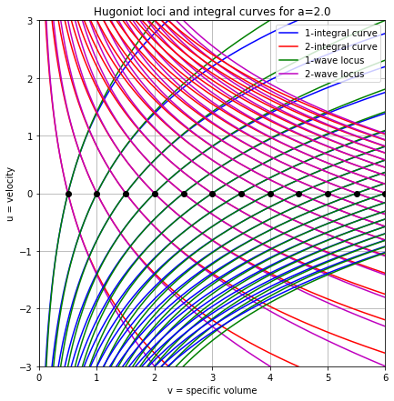

```python
ustar = 0
vstars = arange(0.5,10.5,0.5)
a = 2.0
v = linspace(0.01,10,1000)

fig = figure(figsize=(7, 7))
ax = fig.add_subplot()
grid()
ax.set_aspect('equal', adjustable='box')

for index1 in range(len(vstars)):
    PlotLoci(v,vstars[index1],ustar,a,index1)
```

The color of each curve is described in the legend.

**Question 5.**

Given the physical interpretation of this system (and remembering that $q=(v,u)$), we expect that if $q_\ell = (1,-2)$ and $q_r = (1,2)$, then the solution to the Riemann problem with this data should consist of two rarefaction waves. For the case $a=2$, determine the middle state $q_m$ for this solution. You should be able to solve this analytically.

Confirm that this is the physically correct solution by considering how the relevant eigenvalue varies as you move from $q_\ell$ to $q_m$ to $q_r$.

*Note:* You do not need to find the form of the rarefaction waves $\tilde q(x/t)$ for this homework. But you will for the next homework, so you might want to think about this too.

**Solution:**

We want to go from $q_l$ along the $1-$integral curve to $q_m$ and from $q_r$ along the $2-$integral curve to $q_m$. Thus: $$\begin{cases}u_m&=u_l+a\ln(v_m)-a\ln(v_l),\\ u_m&=u_r-a\ln(v_m)+a\ln(v_r).\end{cases} $$ Therefore we find $v_m$, by equating both equations: $$u_l+a\ln(v_m)-a\ln(v_l)=u_r-a\ln(v_m)+a\ln(v_r)\Rightarrow 2a\ln(v_m)=u_r-u_l+a\ln(v_rv_l)\Rightarrow v_m=\sqrt{v_rv_l}e^{(u_r-u_l)/(2a)}.$$ Therefore, we now find $u_m$: $$u_m = u_l+\ln(\sqrt{v_rv_l}^a)+\frac{u_r-u_l}{2}-\ln(v_l^a)=\frac{u_r+u_l}{2}+\ln\left(\sqrt{\frac{v_r}{v_l}}^a\right).$$ In conclusion we have $$q_m=\begin{bmatrix}\sqrt{v_rv_l}e^{\frac{u_r-u_l}{2a}} \\ \frac{u_r+u_l}{2}+\ln\left(\sqrt{\frac{v_r}{v_l}}^a\right)\end{bmatrix}=\begin{bmatrix}e \\0\end{bmatrix}$$

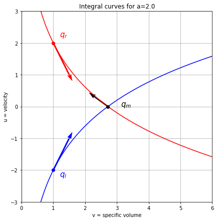

```python
vl = 1
ul = -2
vr = 1
ur = 2
a=2
vm = sqrt(vr*vl)*exp((ur-ul)/(2*a))
um = (ur+ul)/2+a*log(sqrt(vr/vl))

fig = figure(figsize=(7, 7))
ax = fig.add_subplot()
grid()
ax.set_aspect('equal', adjustable='box')
uint1(v,vl,ul,a);
uint2(v,vr,ur,a);
plot(vl,ul,'o', color='blue')
plot(vr,ur,'o', color='red')
plot(vm,um,'o', color='black')
quiver(vl, ul, 1, a/vl, color='blue', scale = 10)
quiver(vr, ur,1, -a/vr, color='red', scale = 10)
quiver(vm, um,-1, a/vm, color='black', scale = 10)

text(vl+.2,ul-.2,'$q_l$', color='blue',fontsize=15)
text(vr+.2,ur+.2,'$q_r$', color='red',fontsize=15)
text(vm+.4,um,'$q_m$', color='black',fontsize=15)
xlim(0,6)
ylim(-3,3)
title('Integral curves for a=%.1f' % a)
xlabel('v = specific volume')
ylabel('u = velocity')
```

Note that we will be following the 1-eigenvalue from $q_l$, which is just following the 1-integral curve, in a positive direction. Once we reach the middle state $q_m$, the crossing of the 1-integral curve and 2-integral curve, we follow the 2-integral in a negative direction (black arrow), to go to $q_r$. Since we do this first in a positive manner and then in a negative manner, on the two integral curves, it's physically correct.

**EXTRA:**

Let's now also try to find the rarefaction waves. We will not do this in the general case, but it should be possible and everything should work out. Simply put, we find the rarefaction related to both families by $$\lambda^\mp(\tilde{v}_\mp(\xi))=\xi\Rightarrow \mp 2/\tilde{v}_\mp(\xi)=\xi\Rightarrow \tilde{v}_\mp=\mp\frac{2t}{x}.$$ Therefore, $$v=\begin{cases} 1 & \frac{x}{t}\leq \lambda^1(q_l)\\ -\frac{at}{x} & \lambda^1(q_l)\leq \frac{x}{t}\leq \lambda^1(q_m)\\ e & \lambda^1(q_m)\leq \frac{x}{t} \leq \lambda^2(q_m)\\ \frac{at}{x}& \lambda^2(q_m)\leq \frac{x}{t}\leq \lambda^2(q_r)\\ 1 & \lambda^2(q_r)\leq \frac{x}{t} \end{cases}= \begin{cases} 1 & x\leq -at,\\ -\frac{at}{x} & -at\leq x\leq -\frac{a}{e}t,\\ e & -\frac{a}{e}t\leq x \leq \frac{a}{e}t,\\ \frac{at}{x}& \frac{a}{e}t\leq x\leq at,\\ 1 & at\leq x. \end{cases}$$ Note that we don't yet have a $\tilde{u}$. We can get this from the PDE and the states: $$\begin{cases}(\tilde{u}_{\mp})_x&=(\tilde{v}_{\mp})_t\\ (\tilde{u}_{\mp})_t&=-(4/(\tilde{v}_{\mp}))_x \end{cases}\Rightarrow \begin{cases} (\tilde{u}_{\mp})_x&=\mp\frac{2}{|x|}\\ (\tilde{u}_{\mp})_t&=\pm\frac{2}{t} \end{cases}\Rightarrow \begin{cases} \tilde{u}_{\mp}&=\mp2\ln(|x|)+C_1(t)\\ \tilde{u}_{\mp}&=\pm2\ln(t)+C_2(x) \end{cases}\Rightarrow u_\mp=\pm2\ln(\frac{t}{|x|})+C_\mp.$$ Now we will use $q_l$ and $q_m$, and, $q_m$ and $q_r$ to find $C_{\mp}$ for both rarefaction waves. Note here that we have 2 conditions per one equation, which might cause it to be overdetermined. It will work out here, and I believe that it eventually all works out in the general cases as well. $$u_-(-2t,t)=-2\Rightarrow -2\ln(2)+C_-=-2\Rightarrow C_-=-2+2\ln(2),$$ note that $$u_-(-2t/e,t)=-2\ln(2/e)-2+2\ln(2)=2-2\ln(2)-2+2\ln(2)=0.$$ Now for the other one, $$u_+(2t,t)=2\Rightarrow 2\ln(2)+C_+=2\Rightarrow C_+=2-2\ln(2),$$ note that $$u_+(2t/e,t)=2\ln(2/e)+2-2\ln(2)=-2+2\ln(2)+2-2\ln(2)=0.$$ In conclusion: $$u= \begin{cases} -2 & x\leq -at\\ 2\ln(-\frac{t}{x})-2+2\ln(2)& -at\leq x\leq -\frac{a}{e}t\\ 0 & -\frac{a}{e}t\leq x \leq \frac{a}{e}t\\ -2\ln(\frac{t}{x})+2-2\ln(2) & \frac{a}{e}t\leq x\leq at\\ 2 & at\leq x \end{cases}$$ and, $$v= \begin{cases} 1 & x\leq -at\\ -\frac{at}{x} & -at\leq x\leq -\frac{a}{e}t\\ e & -\frac{a}{e}t\leq x \leq \frac{a}{e}t\\ \frac{at}{x}& \frac{a}{e}t\leq x\leq at\\ 1 & at\leq x \end{cases}$$ We animate this as follows:

```python
def Finduv(x,t):
    v = zeros(len(x))
    u = zeros(len(x))
    for index1 in range(len(x)):
        if x[index1]<=-a*t:
            v[index1] = 1
            u[index1] = -2
        elif (-a*t<x[index1]) & (x[index1]<-a*t/exp(1)):
            v[index1] = -a*t/x[index1]
            u[index1] = 2*log(-t/x[index1])-2+2*log(2)
        elif (-a*t/exp(1)<=x[index1]) & (x[index1]<=a*t/exp(1)):
            v[index1] = exp(1)
            u[index1] = 0
        elif (a*t/exp(1)<x[index1]) & (x[index1]<a*t):
            v[index1] = a*t/x[index1]
            u[index1] = -(2*log(t/x[index1])-2+2*log(2))
        else:
            v[index1] = 1
            u[index1] = 2
    return v, u
```

```python
def Plotting5(x,t):
    v, u = Finduv(x,t)
    subplot(2,1,1)
    plot(x[1:-1], v[1:-1])
    ylim([.8,exp(1)+.2])
    title('v at time %.1f' % tn)

    subplot(2,1,2)
    plot(x[1:-1], u[1:-1])
    ylim([-2-.2,2+.2])
    title('u at time %.1f' % tn)
    tight_layout()
```

```python
nsteps = 28
nplot = 2.  # how frequently to produce a plot
figs = []  # to accumulate figures for animation
x = linspace(-20,20,100)
dt = .5
for n in range(0,nsteps):
    tn = n*dt
    if mod(n,nplot)==0:
        fig = figure(figsize=(5,5))
        Plotting5(x,tn)
        figs.append(fig)
        close(fig)

anim = animation_tools.animate_figs(figs, figsize=(5,5))
HTML(anim.to_jshtml())
```

[figure not shown]

**Question 6.**

What is the two-shock Riemann solution for arbitrary $q_\ell$ and $q_r$? You should also be able to solve this analytically.

*Hint:* solve a quadratic equation for $\sqrt{v_m}$.

As an example, what is the 2-shock solution for the data from the previous part, $a=2, ~q_\ell = (1,-2)$ and $q_r = (1,2)$?

How far is this from the correct middle state from the 2-rarefaction solution?

**Solution:**

First we look at the $1-$shock and $2-$shock. Thus we have to go from $q_l$ along the $1-$wave locus to $q_m$ and from $q_r$ along the $2-$wave locus to $q_m$. Thus: $$\begin{cases}u_m&=u_l+a\frac{v_m-v_l}{\sqrt{v_mv_l}},\\ u_m&=u_r-a\frac{v_m-v_r}{\sqrt{v_mv_r}}.\end{cases} $$ Therefore we find $v_m$, by equating both equations: \begin{align*} &u_l+a\frac{v_m-v_l}{\sqrt{v_mv_l}}=u_r-a\frac{v_m-v_r}{\sqrt{v_mv_r}}\\ \Rightarrow& \sqrt{v_m}\sqrt{v_rv_l}(u_r-u_l)=a(\sqrt{v_l}+\sqrt{v_r})v_m-a(v_r\sqrt{v_l}+v_l\sqrt{v_r})\\ \stackrel{y=\sqrt{v_m}}{\Rightarrow}&-a(\sqrt{v_l}+\sqrt{v_r})y^2+\sqrt{v_rv_l}(u_r-u_l)y+a(v_r\sqrt{v_l}+v_l\sqrt{v_r})=0\\ \Rightarrow &y=\frac{\sqrt{v_rv_l}(u_l-u_r)\pm\sqrt{(u_l-u_r)^2v_rv_l+4a^2(\sqrt{v_l}+\sqrt{v_r})(v_r\sqrt{v_l}+v_l\sqrt{v_r})}}{-2a(\sqrt{v_l}+\sqrt{v_r})}.\\ \Rightarrow &y=\frac{\sqrt{v_rv_l}(u_l-u_r)\pm\sqrt{(u_l-u_r)^2v_rv_l+4a^2\sqrt{v_lv_r}(\sqrt{v_l}+\sqrt{v_r})^2}}{-2a(\sqrt{v_l}+\sqrt{v_r})}.\end{align*} Since $y=\sqrt{v_m}$ and thus $y>0$, we must have that $\sqrt{v_rv_l}(u_l-u_r)\pm\sqrt{(u_l-u_r)^2v_rv_l+4a^2(\sqrt{v_l}+\sqrt{v_r})(v_r\sqrt{v_l}+v_l\sqrt{v_r})}<0$ and since $4a^2(\sqrt{v_l}+\sqrt{v_r})(v_r\sqrt{v_l}+v_l\sqrt{v_r})>0$, we have that that the numerator is negative only when the sign used is negative. Thus we only have solution $$y=\frac{\sqrt{v_rv_l}(u_l-u_r)-\sqrt{(u_l-u_r)^2v_rv_l+4a^2\sqrt{v_lv_r}(\sqrt{v_l}+\sqrt{v_r})^2}}{-2a(\sqrt{v_l}+\sqrt{v_r})}.$$ Therefore, $$v_m=\left(\frac{\sqrt{v_rv_l}(u_l-u_r)-\sqrt{(u_l-u_r)^2v_rv_l+4a^2\sqrt{v_lv_r}(\sqrt{v_l}+\sqrt{v_r})^2}}{-2a(\sqrt{v_l}+\sqrt{v_r})}\right)^2. $$ We now find $u_m$: \begin{align*}u_m&=u_r-a\sqrt{\frac{v_m}{v_r}}+a\sqrt{\frac{v_r}{v_m}}\\ &= u_r-a\frac{\sqrt{v_rv_l}(u_l-u_r)-\sqrt{(u_l-u_r)^2v_rv_l+4a^2\sqrt{v_lv_r}(\sqrt{v_l}+\sqrt{v_r})^2}}{-2a(\sqrt{v_l}+\sqrt{v_r})\sqrt{v_r}}+a\frac{-2a(\sqrt{v_l}+\sqrt{v_r})\sqrt{v_r}}{\sqrt{v_rv_l}(u_l-u_r)-\sqrt{(u_l-u_r)^2v_rv_l+4a^2\sqrt{v_lv_r}(\sqrt{v_l}+\sqrt{v_r})^2}} \end{align*} Finding $u_m$ is a hustle, therefore we fill in $q_l$ and $q_r$ already: $$v_m=\left(\frac{1+\sqrt{1+a^2}}{a}\right)^2.$$ Therefore, $$u_m= 2-a\frac{\sqrt{1+a^2}+1}{a}+\frac{a^2}{\sqrt{1+a^2}+1}=\frac{2\sqrt{1+a^2}+2-1-a^2-1-2\sqrt{1+a^2}+a^2}{\sqrt{1+a^2}+1}=0. $$ Filling in $a$ now gives us $$q_m=\begin{bmatrix}\left(\frac{1+\sqrt{5}}{2}\right)^2\\0\end{bmatrix}=\begin{bmatrix}\phi^2\\0\end{bmatrix},$$ with $\phi$ being the golden ratio.

The difference between the physically correct middlestate and this one is not that large:

$$\begin{bmatrix}|e-\phi^2|\\0\end{bmatrix}=$$

```python
abs(exp(1)-((1+sqrt(5))/2)**2)
```

```
0.10024783970915019
```

**Question 7.**

Produce a phase plane plot that shows $q_\ell,~q_m,~q_r$, and the curves connecting them from the answer to Question 5, and also the Hugoniot loci from Question 6.

**Solution:**

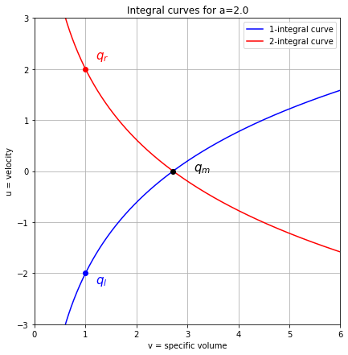

```python
vm = sqrt(vr*vl)*exp((ur-ul)/(2*a))
um = (ur+ul)/2+a*log(sqrt(vr/vl))
fig = figure(figsize=(7, 7))
ax = fig.add_subplot()
grid()
ax.set_aspect('equal', adjustable='box')
uint1(v,vl,ul,a);
uint2(v,vr,ur,a);
plot(vl,ul,'o', color='blue')
plot(vr,ur,'o', color='red')
plot(vm,um,'o', color='black')
text(vl+.2,ul-.2,'$q_l$', color='blue',fontsize=15)
text(vr+.2,ur+.2,'$q_r$', color='red',fontsize=15)
text(vm+.4,um,'$q_m$', color='black',fontsize=15)
xlim(0,6)
ylim(-3,3)
title('Integral curves for a=%.1f' % a)
xlabel('v = specific volume')
ylabel('u = velocity')
legend()
```

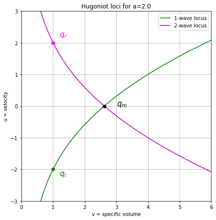

```python
d = -a*(sqrt(vl)+sqrt(vr))
b = (ul-ur)*sqrt(vr*vl)
c = a*(vr*sqrt(vl)+vl*sqrt(vr))
vm =((-b+sqrt(b**2-4*d*c))/(2*d))**2
um = ur-a*sqrt(vm/vr)+a*sqrt(vr/vm)
fig = figure(figsize=(7, 7))
ax = fig.add_subplot()
grid()
ax.set_aspect('equal', adjustable='box')
uhug1(v,vl,ul,a);
uhug2(v,vr,ur,a);
plot(vl,ul,'o', color='green')
plot(vr,ur,'o', color='magenta')
plot(vm,um,'o', color='black')
text(vl+.2,ul-.2,'$q_l$', color='green',fontsize=15)
text(vr+.2,ur+.2,'$q_r$', color='magenta',fontsize=15)
text(vm+.4,um,'$q_m$', color='black',fontsize=15)
xlim(0,6)
ylim(-3,3)
title('Hugoniot loci for a=%.1f' % a)
xlabel('v = specific volume')
ylabel('u = velocity')
legend()
```

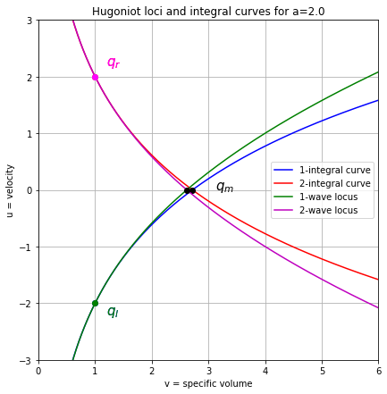

```python
vm = sqrt(vr*vl)*exp((ur-ul)/(2*a))
um = (ur+ul)/2+a*log(sqrt(vr/vl))
fig = figure(figsize=(7, 7))
ax = fig.add_subplot()
grid()
ax.set_aspect('equal', adjustable='box')
uint1(v,vl,ul,a);
uint2(v,vr,ur,a);
plot(vl,ul,'o', color='blue')
plot(vr,ur,'o', color='red')
plot(vm,um,'o', color='black')
text(vl+.2,ul-.2,'$q_l$', color='blue',fontsize=15)
text(vr+.2,ur+.2,'$q_r$', color='red',fontsize=15)
text(vm+.4,um,'$q_m$', color='black',fontsize=15)
xlim(0,6)
ylim(-3,3)
title('Hugoniot loci and integral curves for a=%.1f' % a)
xlabel('v = specific volume')
ylabel('u = velocity')
d = -a*(sqrt(vl)+sqrt(vr))
b = (ul-ur)*sqrt(vr*vl)
c = a*(vr*sqrt(vl)+vl*sqrt(vr))
vm =((-b+sqrt(b**2-4*d*c))/(2*d))**2
um = ur-a*sqrt(vm/vr)+a*sqrt(vr/vm)
uhug1(v,vl,ul,a);
uhug2(v,vr,ur,a);
plot(vl,ul,'o', color='green')
plot(vr,ur,'o', color='magenta')
plot(vm,um,'o', color='black')
text(vl+.2,ul-.2,'$q_l$', color='green',fontsize=15)
text(vr+.2,ur+.2,'$q_r$', color='magenta',fontsize=15)
legend()
```